# Sensitivity and Specificity

October 5, 2015

## Readings

*APM*

- *Chapter 5 Measuring Performance in Regression Models* (esp. *5.2 The Variance Bias Trade-Off*) (5 pages)
- *Chapter 11 Measuring Performance in Classification Models* (~20 pages)
- *Chapter 7.4 K-Nearest Neighbors (regression)* (2 pages)
- *Chapter 13.5 K-Nearest Neighbors (classification)* (3 pages)

## EXERCISE 1: Resampling

`x` is a random variable. We want to not only know what the `mean(x)` is but want to calculate the uncertainty of `mean(x)`. Measuring the uncertainty requires repeated measurements of `mean(x)`.

- Calculate the mean of `x`.
- Calculte the `sd( mean(x) )` using the **using 10-fold cross-validation**. Create your own folds, show your work. (An example is for the Bootstrap is given as a hint. )

```r
set.seed(1)
for (k in 1:10) {
  x <- runif(20,1,20)
}



x_mean = mean(x)

k=10

# CROSS-VALIDATION
# ... YOUR WORK HWEW

x_mean<- numeric()
for(k in 1:10) {
  x_mean <- append( x_mean, sample(x,replace=TRUE) %>% mean)
}
sd_cv <- sd(x_mean)
sd_cv
```

```
## [1] 1.510089
```

```r
# BOOTSTRAP (EXAMPLE)
sd_boot <- sapply(1:k, function(i) sample(x,replace=TRUE) %>% mean ) %>% sd
sd_boot
```

```
## [1] 0.7683983
```

- sd_cv is: 1.5100885
- sd_boot is: 0.7683983

# Exercise 2: Binomial Metrics

Here’s a really simple Model of Versicolor iris based on the **iris** data :

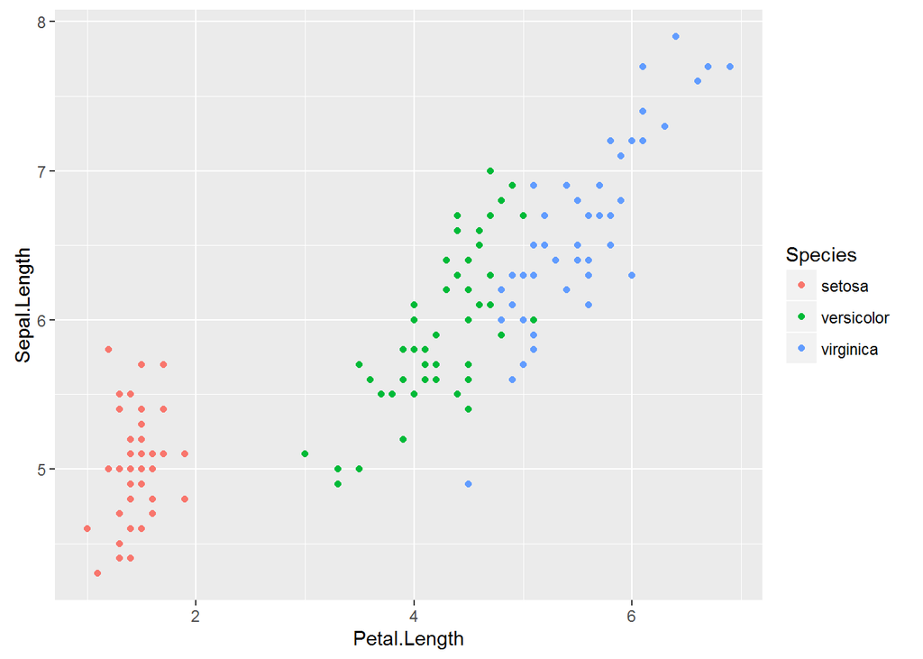

```r
set.seed(1)
data(iris)

qplot( data=iris, x=Petal.Length, y=Sepal.Length, color=Species )
```

```r
# Create Dependent Variable
iris$Versicolor <-
  ifelse( iris$Species == 'versicolor', "versicolor", "other" ) %>% as.factor
iris$Species = NULL

wh <- sample.int( nrow(iris), size=nrow(iris)/2 )
train <- iris[ wh,]
test <- iris[ -wh, ]


fit.glm <- glm( Versicolor ~ . - Sepal.Length, data=train, family=binomial )
```

Use the models to and write functions to calculate:

The functions should take two logical vectors of the same length, `y` and `yhat`

```r
prevalence = function(y,yhat) {(sum(yhat)+sum(!yhat))/(sum(y)+sum(!y)+sum(yhat)+sum(!yhat))}
accuracy   =  function(y,yhat) {(sum(yhat & y)+sum(!yhat & !y))/(sum(y)+sum(!y))}
error_rate =  function(y,yhat) {(sum(yhat & y)+sum(!yhat & !y))/(sum(y)+sum(!y))}
tpr = function(y,yhat) {(sum(yhat & y))/sum(y)}
fpr =     # See Example
tnr = function(y,yhat) {(sum(!yhat & !y))/(sum(!y))}
sensitivity = function(y,yhat) {(sum(yhat & y))/(sum(y))}
specificity = function(y,yhat) {(sum(!yhat & !y))/(sum(!y))}
recall = function(y,yhat) {(sum(yhat & y))/(sum(y))}
precision = function(y,yhat) {(sum(yhat & y))/(sum(yhat))}

# EXAMPLE: fpr
# The FPR is THE NUMBER OF FALSE POSITIVES / NEGATIVES (TN+FP)

threshold = 0.5
y = test$Versicolor == 'versicolor'
yhat = predict(fit.glm, test, type="response") > threshold


fpr = function(y,yhat)
  sum(yhat & !y)  / # FP
  sum(! y)                # N

fpr(y,yhat)
```

```
## [1] 0.1886792
```

```r
##AL: see wikipedia page
prevalence(y,yhat)
```

```
## [1] 0.5
```

```r
accuracy (y,yhat)
```

```
## [1] 0.7333333
```

```r
error_rate(y,yhat)
```

```
## [1] 0.7333333
```

```r
tpr (y,yhat)
```

```
## [1] 0.5454545
```

```r
fpr (y,yhat)
```

```
## [1] 0.1886792
```

```r
tnr (y,yhat)
```

```
## [1] 0.8113208
```

```r
sensitivity(y,yhat)
```

```
## [1] 0.5454545
```

```r
specificity(y,yhat)
```

```
## [1] 0.8113208
```

```r
recall(y,yhat)
```

```
## [1] 0.5454545
```

```r
precision (y,yhat)
```

```
## [1] 0.5454545
```

- What is wrong with the modeling approach used?